# Random Forests Lab

Insofe Lab - Batch 47

4th Nov 2018

# Random Forests

Decision Trees typically tend to overfit and result in a high variance model. To reduce overfitting in decision trees, random feature sub-spaces is used where a portion of the attributes are used to build multiple trees. The majority vote from the trees are used for prediction. As a result, the model can generalize better.

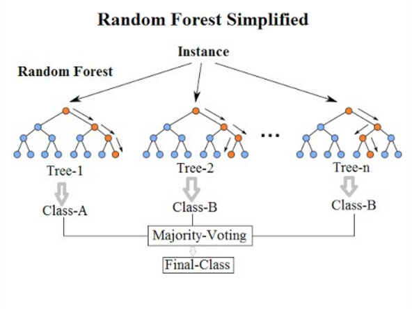

## Clear Environment

```r
rm(list = ls(all = T))
```

## Load the required libraries

```r
library(DMwR)
# This library has some function we use quite often, such as KNN and Cetnral Imputation, regr.eval(), SMOTE, manyNAs()

library(randomForest)
# This library has some specific calls for Random Forest Algorithm - The model itself, importance of variables

library(caret)
# Preprocess functions, nearzerovars etc.
```

## Read the data into R

```r
data = read.table('hepatitis.txt', header=F, dec='.',
                  col.names=c('target','age','gender','steroid',
                              'antivirals','fatigue','malaise',
                              'anorexia','liverBig','liverFirm',
                              'spleen','spiders','ascites',
                              'varices','bili','alk','sgot',
                              'albu','protime','histology'),
                  na.strings=c('?'), sep=',')
```

## Understand the data

```r
str(data)
```

```
## 'data.frame':    155 obs. of  20 variables:
##  $ target    : int  2 2 2 2 2 2 1 2 2 2 ...
##  $ age       : int  30 50 78 31 34 34 51 23 39 30 ...
##  $ gender    : int  2 1 1 1 1 1 1 1 1 1 ...
##  $ steroid   : int  1 1 2 NA 2 2 1 2 2 2 ...
##  $ antivirals: int  2 2 2 1 2 2 2 2 2 2 ...
##  $ fatigue   : int  2 1 1 2 2 2 1 2 1 2 ...
##  $ malaise   : int  2 2 2 2 2 2 2 2 2 2 ...
##  $ anorexia  : int  2 2 2 2 2 2 1 2 2 2 ...
##  $ liverBig  : int  1 1 2 2 2 2 2 2 2 2 ...
##  $ liverFirm : int  2 2 2 2 2 2 2 2 1 2 ...
##  $ spleen    : int  2 2 2 2 2 2 1 2 2 2 ...
##  $ spiders   : int  2 2 2 2 2 2 1 2 2 2 ...
##  $ ascites   : int  2 2 2 2 2 2 2 2 2 2 ...
##  $ varices   : int  2 2 2 2 2 2 2 2 2 2 ...
##  $ bili      : num  1 0.9 0.7 0.7 1 0.9 NA 1 0.7 1 ...
##  $ alk       : int  85 135 96 46 NA 95 NA NA NA NA ...
##  $ sgot      : int  18 42 32 52 200 28 NA NA 48 120 ...
##  $ albu      : num  4 3.5 4 4 4 4 NA NA 4.4 3.9 ...
##  $ protime   : int  NA NA NA 80 NA 75 NA NA NA NA ...
##  $ histology : int  1 1 1 1 1 1 1 1 1 1 ...
```

```r
summary(data)
```

```
##      target           age           gender         steroid
##  Min.   :1.000   Min.   : 7.0   Min.   :1.000   Min.   :1.000
##  1st Qu.:2.000   1st Qu.:32.0   1st Qu.:1.000   1st Qu.:1.000
##  Median :2.000   Median :39.0   Median :1.000   Median :2.000
##  Mean   :1.794   Mean   :41.2   Mean   :1.103   Mean   :1.506
##  3rd Qu.:2.000   3rd Qu.:50.0   3rd Qu.:1.000   3rd Qu.:2.000
##  Max.   :2.000   Max.   :78.0   Max.   :2.000   Max.   :2.000
##                                                 NA's   :1
##    antivirals       fatigue         malaise         anorexia
##  Min.   :1.000   Min.   :1.000   Min.   :1.000   Min.   :1.000
##  1st Qu.:2.000   1st Qu.:1.000   1st Qu.:1.000   1st Qu.:2.000
##  Median :2.000   Median :1.000   Median :2.000   Median :2.000
##  Mean   :1.845   Mean   :1.351   Mean   :1.604   Mean   :1.792
##  3rd Qu.:2.000   3rd Qu.:2.000   3rd Qu.:2.000   3rd Qu.:2.000
##  Max.   :2.000   Max.   :2.000   Max.   :2.000   Max.   :2.000
##                  NA's   :1       NA's   :1       NA's   :1
##     liverBig       liverFirm         spleen       spiders
##  Min.   :1.000   Min.   :1.000   Min.   :1.0   Min.   :1.00
##  1st Qu.:2.000   1st Qu.:1.000   1st Qu.:2.0   1st Qu.:1.00
##  Median :2.000   Median :2.000   Median :2.0   Median :2.00
##  Mean   :1.828   Mean   :1.583   Mean   :1.8   Mean   :1.66
##  3rd Qu.:2.000   3rd Qu.:2.000   3rd Qu.:2.0   3rd Qu.:2.00
##  Max.   :2.000   Max.   :2.000   Max.   :2.0   Max.   :2.00
##  NA's   :10      NA's   :11      NA's   :5     NA's   :5
##     ascites         varices          bili            alk
##  Min.   :1.000   Min.   :1.00   Min.   :0.300   Min.   : 26.00
##  1st Qu.:2.000   1st Qu.:2.00   1st Qu.:0.700   1st Qu.: 74.25
##  Median :2.000   Median :2.00   Median :1.000   Median : 85.00
##  Mean   :1.867   Mean   :1.88   Mean   :1.428   Mean   :105.33
##  3rd Qu.:2.000   3rd Qu.:2.00   3rd Qu.:1.500   3rd Qu.:132.25
##  Max.   :2.000   Max.   :2.00   Max.   :8.000   Max.   :295.00
##  NA's   :5       NA's   :5      NA's   :6       NA's   :29
##       sgot             albu          protime         histology
##  Min.   : 14.00   Min.   :2.100   Min.   :  0.00   Min.   :1.000
##  1st Qu.: 31.50   1st Qu.:3.400   1st Qu.: 46.00   1st Qu.:1.000
##  Median : 58.00   Median :4.000   Median : 61.00   Median :1.000
##  Mean   : 85.89   Mean   :3.817   Mean   : 61.85   Mean   :1.452
##  3rd Qu.:100.50   3rd Qu.:4.200   3rd Qu.: 76.25   3rd Qu.:2.000
##  Max.   :648.00   Max.   :6.400   Max.   :100.00   Max.   :2.000
##  NA's   :4        NA's   :16      NA's   :67
```

### Check the count of target variable values

```r
table(data$target)
```

```
##
##   1   2
##  32 123
```

```r
str(data$target) # 1: Die; 2: Live
```

```
##  int [1:155] 2 2 2 2 2 2 1 2 2 2 ...
```

## Convert data to the required format

### Convert 1s and 2s into 1s and 0s

```r
# 1: Die(+ve); 0: Live (-ve)
data$target= ifelse(data$target==1, 1, 0 )
```

### Separate Categorical and Numerical Variables

```r
# The numerical variables are: age, bili, alk, sgot, albu and protime
# The categorical variables are: the remaining 14 variables

num_Attr = c("age", "bili", "alk", "sgot", "albu", "protime")
cat_Attr = setdiff(names(data), num_Attr)
cat_Attr
```

```
##  [1] "target"     "gender"     "steroid"    "antivirals" "fatigue"
##  [6] "malaise"    "anorexia"   "liverBig"   "liverFirm"  "spleen"
## [11] "spiders"    "ascites"    "varices"    "histology"
```

```r
# Separate numerical and categorical variables and convert them into appropriate type

cat_Data = data.frame(sapply(data[,cat_Attr], as.factor))
num_Data = data.frame(sapply(data[,num_Attr], as.numeric))
data = cbind(num_Data, cat_Data)

# Remove variable that are not needed further
rm(num_Attr, cat_Attr)
rm(cat_Data, num_Data)
```

## Split dataset into train and test

```r
set.seed(009)

train_RowIDs = sample(1:nrow(data), nrow(data)*0.7)
train_Data = data[train_RowIDs,]
test_Data = data[-train_RowIDs,]

rm(train_RowIDs)
```

## Check how records are split with respect to target attribute

```r
table(data$target)
```

```
##
##   0   1
## 123  32
```

```r
table(train_Data$target)
```

```
##
##  0  1
## 85 23
```

```r
table(test_Data$target)
```

```
##
##  0  1
## 38  9
```

```r
# Note : # As part of Pre-processing, Imputation and scaling are done after train-evaluation/test split
```

## Check to see if missing values in data

```r
sum(is.na(train_Data))
```

```
## [1] 112
```

```r
sum(is.na(test_Data))
```

```
## [1] 55
```

## Imputing missing values using KNN

```r
# Impute for train data
train_Data <- knnImputation(data = train_Data, k = 5)
sum(is.na(train_Data))
```

```
## [1] 0
```

```r
# Impute for test data
test_Data <- knnImputation(data = test_Data, k = 5, distData = train_Data)
sum(is.na(test_Data))
```

```
## [1] 0
```

## Model Building

### Build the classification model using randomForest

```r
set.seed(123)


model = randomForest(target ~ ., data=train_Data,
                     keep.forest=TRUE, ntree=200)

# Print and understand the model
print(model)
```

```
##
## Call:
##  randomForest(formula = target ~ ., data = train_Data, keep.forest = TRUE,      ntree = 200)
##                Type of random forest: classification
##                      Number of trees: 200
## No. of variables tried at each split: 4
##
##         OOB estimate of  error rate: 15.74%
## Confusion matrix:
##    0  1 class.error
## 0 79  6  0.07058824
## 1 11 12  0.47826087
```

### Notes on the model:

- No. of variables tried at each split = floor(sqrt(ncol(train_Data) - 1))
- Out-of-Bag is equivalent to validation or test data.
- It is estimated internally, during the run, as follows: As the forest is built on training data , each tree is tested on the 1/3rd of the samples (36.8%) not used in building that tree (similar to validation data set). This is the out of bag error estimate - an internal error estimate of a random forest as it is being constructed.

## Important attributes

- Important attributes derived from Random Forest models are often used to simplify the model

```r
model$importance
```

```
##            MeanDecreaseGini
## age               3.0188108
## bili              3.6181103
## alk               3.7516899
## sgot              1.6973091
## albu              4.6320986
## protime           7.4966442
## gender            0.5484799
## steroid           0.4297936
## antivirals        0.2311385
## fatigue           0.3940870
## malaise           0.7009324
## anorexia          0.5479326
## liverBig          0.2073866
## liverFirm         0.6420283
## spleen            1.0835123
## spiders           2.4309187
## ascites           0.9994390
## varices           1.7803781
## histology         1.4004859
```

## Extract and store important variables obtained from the random forest model

```r
rf_Imp_Attr = data.frame(model$importance)
rf_Imp_Attr = data.frame(row.names(rf_Imp_Attr),rf_Imp_Attr[,1])
rf_Imp_Attr
```

```
##    row.names.rf_Imp_Attr. rf_Imp_Attr...1.
## 1                     age        3.0188108
## 2                    bili        3.6181103
## 3                     alk        3.7516899
## 4                    sgot        1.6973091
## 5                    albu        4.6320986
## 6                 protime        7.4966442
## 7                  gender        0.5484799
## 8                 steroid        0.4297936
## 9              antivirals        0.2311385
## 10                fatigue        0.3940870
## 11                malaise        0.7009324
## 12               anorexia        0.5479326
## 13               liverBig        0.2073866
## 14              liverFirm        0.6420283
## 15                 spleen        1.0835123
## 16                spiders        2.4309187
## 17                ascites        0.9994390
## 18                varices        1.7803781
## 19              histology        1.4004859
```

```r
colnames(rf_Imp_Attr) = c('Attributes', 'Importance')
rf_Imp_Attr = rf_Imp_Attr[order(rf_Imp_Attr$Importance, decreasing = TRUE),]
rf_Imp_Attr
```

```
##    Attributes Importance
## 6     protime  7.4966442
## 5        albu  4.6320986
## 3         alk  3.7516899
## 2        bili  3.6181103
## 1         age  3.0188108
## 16    spiders  2.4309187
## 18    varices  1.7803781
## 4        sgot  1.6973091
## 19  histology  1.4004859
## 15     spleen  1.0835123
## 17    ascites  0.9994390
## 11    malaise  0.7009324
## 14  liverFirm  0.6420283
## 7      gender  0.5484799
## 12   anorexia  0.5479326
## 8     steroid  0.4297936
## 10    fatigue  0.3940870
## 9  antivirals  0.2311385
## 13   liverBig  0.2073866
```

## Plot (directly prints the important attributes)

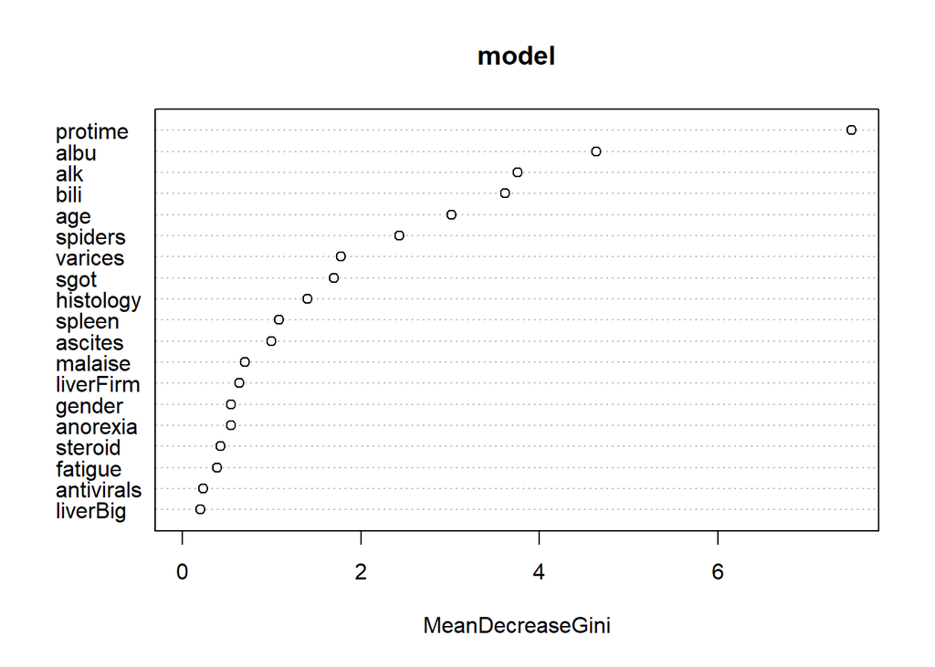

```r
varImpPlot(model)
```

## Predict on Train data

```r
pred_Train = predict(model,
                     train_Data[,setdiff(names(train_Data), "target")],
                     type="response",
                     norm.votes=TRUE)
```

## Build confusion matrix and find accuracy

```r
cm_Train = table("actual"= train_Data$target, "predicted" = pred_Train);
cm_Train
```

```
##       predicted
## actual  0  1
##      0 85  0
##      1  0 23
```

```r
accu_Train= sum(diag(cm_Train))/sum(cm_Train)
accu_Train
```

```
## [1] 1
```

```r
rm(pred_Train, cm_Train)
```

## Predict on Test and Calculate Accuracy

```r
# Predicton Test Data
pred_Test = predict(model, test_Data[,setdiff(names(test_Data),
                                              "target")],
                    type="response",
                    norm.votes=TRUE)

# Build confusion matrix and find accuracy
cm_Test = table("actual"=test_Data$target, "predicted"=pred_Test);
cm_Test
```

```
##       predicted
## actual  0  1
##      0 36  2
##      1  2  7
```

```r
accu_Test= sum(diag(cm_Test))/sum(cm_Test)
accu_Test
```

```
## [1] 0.9148936
```

```r
rm(pred_Test, cm_Test)

accu_Train
```

```
## [1] 1
```

```r
accu_Test
```

```
## [1] 0.9148936
```

## Build random forest using top 12 important attributes

```r
top_Imp_Attr = as.character(rf_Imp_Attr$Attributes[1:12])

set.seed(015)

# Build the classification model using randomForest
model_Imp = randomForest(target~.,
                         data=train_Data[,c(top_Imp_Attr,"target")],
                         keep.forest=TRUE,ntree=100)
```

## Print and understand the model

```r
print(model_Imp)
```

```
##
## Call:
##  randomForest(formula = target ~ ., data = train_Data[, c(top_Imp_Attr,      "target")], keep.forest = TRUE, ntree = 100)
##                Type of random forest: classification
##                      Number of trees: 100
## No. of variables tried at each split: 3
##
##         OOB estimate of  error rate: 15.74%
## Confusion matrix:
##    0  1 class.error
## 0 78  7  0.08235294
## 1 10 13  0.43478261
```

```r
table(train_Data$target)
```

```
##
##  0  1
## 85 23
```

## Important attributes

```r
model_Imp$importance
```

```
##           MeanDecreaseGini
## protime          8.0278462
## albu             5.7798983
## alk              4.3094696
## bili             3.6286566
## age              3.5096758
## spiders          2.9332677
## varices          1.3868815
## sgot             2.1422951
## histology        1.5598093
## spleen           0.8914888
## ascites          1.3131963
## malaise          0.7391316
```

## Predict on Train Data and Calculate Accuracy

```r
# Predict on Train data
pred_Train = predict(model_Imp, train_Data[,top_Imp_Attr],
                     type="response", norm.votes=TRUE)


# Build confusion matrix and find accuracy
cm_Train = table("actual" = train_Data$target,
                 "predicted" = pred_Train);
cm_Train
```

```
##       predicted
## actual  0  1
##      0 85  0
##      1  0 23
```

```r
accu_Train_Imp = sum(diag(cm_Train))/sum(cm_Train)
accu_Train_Imp
```

```
## [1] 1
```

```r
rm(pred_Train, cm_Train)
```

## Predict on Test Data and Calculate Accuracy

```r
# Predicton Test Data
pred_Test = predict(model_Imp, test_Data[,top_Imp_Attr],
                    type="response", norm.votes=TRUE)

# Build confusion matrix and find accuracy
cm_Test = table("actual" = test_Data$target,
                "predicted" = pred_Test);
cm_Test
```

```
##       predicted
## actual  0  1
##      0 34  4
##      1  2  7
```

```r
accu_Test_Imp = sum(diag(cm_Test))/sum(cm_Test)

rm(pred_Test, cm_Test)

accu_Train
```

```
## [1] 1
```

```r
accu_Test
```

```
## [1] 0.9148936
```

```r
accu_Train_Imp
```

```
## [1] 1
```

```r
accu_Test_Imp
```

```
## [1] 0.8723404
```

## Select mtry value with minimum out of bag (OOB) error.

```
## mtry = 4  OOB error = 17.59%
## Searching left ...
## mtry = 3     OOB error = 13.89%
## 0.2105263 0.01
## mtry = 2     OOB error = 14.81%
## -0.06666667 0.01
## Searching right ...
## mtry = 6     OOB error = 17.59%
## -0.2666667 0.01
```

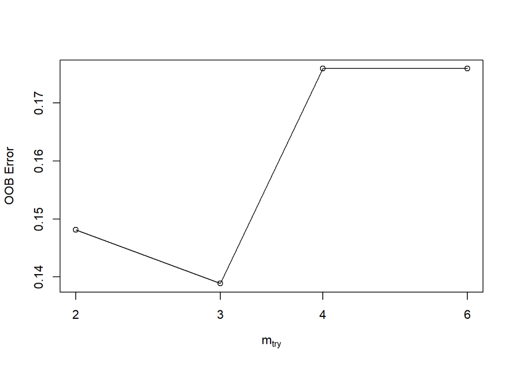

```r
mtry <- tuneRF(train_Data[-7],train_Data$target, ntreeTry=100,
               stepFactor=1.5,improve=0.01, trace=TRUE, plot=TRUE)
```

```r
best.m <- mtry[mtry[, 2] == min(mtry[, 2]), 1]
print(mtry)
```

```
##       mtry  OOBError
## 2.OOB    2 0.1481481
## 3.OOB    3 0.1388889
## 4.OOB    4 0.1759259
## 6.OOB    6 0.1759259
```

```r
print(best.m)
```

```
## [1] 3
```

## Tuning Random Forest Models

- Hyper parameters are variables in a model arrived at through empirical methods
- What are the hyper parameters of Random Forest Models?
  - Number of trees to be built
  - Depth of trees
  - Number of columns to use for tree building (Mtry)

## Parameters in tuneRF function

- The stepFactor specifies at each iteration, mtry is inflated (or deflated) by this value
- The improve specifies the (relative) improvement in OOB error must be by this much for the search to continue
- The trace specifies whether to print the progress of the search
- The plot specifies whether to plot the OOB error as function of mtry

## Build Model with best mtry again

```r
 set.seed(71)

rf <- randomForest(target~.,data=train_Data, mtry=best.m, importance=TRUE,ntree=100)
print(rf)
```

```
##
## Call:
##  randomForest(formula = target ~ ., data = train_Data, mtry = best.m,      importance = TRUE, ntree = 100)
##                Type of random forest: classification
##                      Number of trees: 100
## No. of variables tried at each split: 3
##
##         OOB estimate of  error rate: 16.67%
## Confusion matrix:
##    0  1 class.error
## 0 78  7  0.08235294
## 1 11 12  0.47826087
```

## Important attributes - New Model

```r
# Evaluate variable importance
importance(rf)
```

```
##                      0           1 MeanDecreaseAccuracy MeanDecreaseGini
## age        -0.23639310  0.45695793            0.3930367        2.7538370
## bili       -0.35183735  1.54392042            0.8150085        3.7868301
## alk         1.74336223 -0.60463621            0.9064655        3.3535946
## sgot       -0.02411803 -1.37455443           -0.7428431        1.4647569
## albu        2.69531801  5.49850361            5.2392614        5.9262112
## protime     3.74682343  7.36731804            7.1660653        6.5999056
## gender      2.08120062  2.07635432            2.6141039        0.5752842
## steroid    -1.78325365 -0.04826242           -1.6622987        0.4785847
## antivirals  1.10222446  1.05305974            1.5656468        0.1839160
## fatigue    -1.39447726  0.77182522           -0.3663837        0.3731224
## malaise     2.24650055  0.46555606            1.9026186        0.8883867
## anorexia    0.98877010 -1.94415827           -0.1193256        0.5516264
## liverBig   -1.05896463 -2.07737131           -2.0760977        0.3890657
## liverFirm  -0.03677908 -1.47295736           -1.0996743        0.4716389
## spleen      0.75886466  3.19024945            2.8419769        1.1613619
## spiders     2.70288074  2.46304237            3.0625117        2.4636479
## ascites     1.63283722  1.43082539            2.1196168        0.8446984
## varices     1.81670244  2.34020210            2.8481827        1.2905026
## histology  -0.71352485  4.27549015            3.2456573        1.5595509
```

```r
# Important attributes
model$importance
```

```
##            MeanDecreaseGini
## age               3.0188108
## bili              3.6181103
## alk               3.7516899
## sgot              1.6973091
## albu              4.6320986
## protime           7.4966442
## gender            0.5484799
## steroid           0.4297936
## antivirals        0.2311385
## fatigue           0.3940870
## malaise           0.7009324
## anorexia          0.5479326
## liverBig          0.2073866
## liverFirm         0.6420283
## spleen            1.0835123
## spiders           2.4309187
## ascites           0.9994390
## varices           1.7803781
## histology         1.4004859
```

## Extract and store important variables obtained from the random forest model

```r
rf_Imp_Attr = data.frame(model$importance)
rf_Imp_Attr = data.frame(row.names(rf_Imp_Attr),rf_Imp_Attr[,1])
colnames(rf_Imp_Attr) = c('Attributes', 'Importance')
rf_Imp_Attr = rf_Imp_Attr[order(rf_Imp_Attr$Importance, decreasing = TRUE),]
```

## Predict on Train Data and Calculate Accuracy

```r
# Predict on Train data
pred_Train = predict(model,
                     train_Data[,setdiff(names(train_Data), "target")],
                     type="response",
                     norm.votes=TRUE)

# Build confusion matrix and find accuracy
cm_Train = table("actual"= train_Data$target, "predicted" = pred_Train)
cm_Train
```

```
##       predicted
## actual  0  1
##      0 85  0
##      1  0 23
```

```r
accu_Train = sum(diag(cm_Train))/sum(cm_Train)
rm(pred_Train, cm_Train)
```

## Predict on Test Data and Calculate Accuracy

```r
# Predicton Test Data
pred_Test = predict(model, test_Data[,setdiff(names(test_Data),
                                              "target")],
                    type="response",
                    norm.votes=TRUE)

# Build confusion matrix and find accuracy
cm_Test = table("actual"=test_Data$target, "predicted"=pred_Test)
cm_Test
```

```
##       predicted
## actual  0  1
##      0 36  2
##      1  2  7
```

```r
accu_Test= sum(diag(cm_Test))/sum(cm_Test)
rm(cm_Test)

accu_Train
```

```
## [1] 1
```

```r
accu_Test
```

```
## [1] 0.9148936
```